# RNA-seq analysis in R

Solutions: Analysis of Pasilla Knock-down Experiment in Drosophila

Belinda Phipson and Jovana Maksimovic

21, 23 September 2016

**Author: Belinda Phipson and Jovana Maksimovic**

## Data files needed

- counts_Drosophila.txt
- SampleInfo_Drosophila.txt

Available from https://figshare.com/s/e08e71c42f118dbe8be6.

## Libraries needed

- limma
- edgeR
- org.Dm.eg.db
- gplots
- RColorBrewer

## Introduction

The RNA-Seq data we will be analysing today come from this published paper:

Brooks, A.N., Yang, L., Duff, M.O., Hansen, K.D., Park, J.W., Dudoit, S., Brenner, S.E. and Graveley, B.R. (2011) Conservation of an rna regulatory map between drosophila and mammals. Genome Research, 21(2), 193-202.  
http://www.ncbi.nlm.nih.gov/pubmed/20921232

This is a publicly available dataset, deposited in the Short Read Archive. The RNA-sequence data are available from GEO under accession nos. GSM461176-GSM461181. The authors combined RNAi and RNASeq to identify exons regulated by Pasilla, the Drosophila melanogaster ortholog of mammalian NOVA1 and NOVA2. They showed that the RNA regulatory map of Pasilla and NOVA1/2 is highly conserved between insects and mammals. NOVA1 and NOVA2 are best known for being involved in alternative splicing. Cells from S2-DRSC, which is an embryonic cell line, were cultured and subjected to a treatment in order to knock-down Pasilla. The four untreated and three treated RNAi samples were used in the analysis. The treated samples had Pasilla knocked down by approximately 60% compared to the untreated samples. Some of the samples had undergone paired end sequencing while other samples were sequenced from one end only.

The reads were aligned to the Drosophila reference genome, downloaded from Ensembl, using the tophat aligner. The reads were summarised at the gene-level using htseq-count, a function from the tool HTSeq (http://wwwhuber.embl.de/users/anders/HTSeq/doc/overview.html).

For the purpose of today’s workshop, we will be analysing the gene level counts.

## Reading data into R

First, let’s load all the libraries we will need today.

```r
library(limma)
library(edgeR)
```

```r
library(gplots)
library(RColorBrewer)
library(org.Dm.eg.db)
```

Next, read in the data and targets file:

```r
counts <- read.delim(file="data/counts_Drosophila.txt")
targets <- read.delim(file="data/SampleInfo_Drosophila.txt")
```

Check that the data has read in correctly

```r
head(counts)
```

```
            SRR031714.bam SRR031716.bam SRR031724.bam SRR031726.bam
FBgn0037213           157           142           213           291
FBgn0000500             0             3             4             5
FBgn0053294            14            18            13            19
FBgn0037215          1666          1948          1662          1833
FBgn0037217            13            19            18            23
FBgn0037218           732           755           803           906
            SRR031708.bam SRR031718.bam SRR031728.bam
FBgn0037213           123           225           164
FBgn0000500             2             1             1
FBgn0053294            22            34            22
FBgn0037215          1625          1701          1870
FBgn0037217            15            15            17
FBgn0037218           695           767           793
```

```r
targets
```

```
  SampleName     Group Library
1  SRR031714 Untreated      PE
2  SRR031716 Untreated      PE
3  SRR031724   Treated      PE
4  SRR031726   Treated      PE
5  SRR031708 Untreated      SE
6  SRR031718   Treated      SE
7  SRR031728 Untreated      SE
```

## Filtering out lowly expressed genes

Our main interest is in testing the treated versus untreated groups. To check how many samples we have in each group we can use the `table` command.

```r
table(targets$Group)
```

```
  Treated Untreated
        3         4
```

The minimum sample size is 3. Let’s check the relationship between CPM and counts to see what CPM threshold we should be imposing. Recall we’re looking for a CPM that corresponds to a count of roughly 10-15.

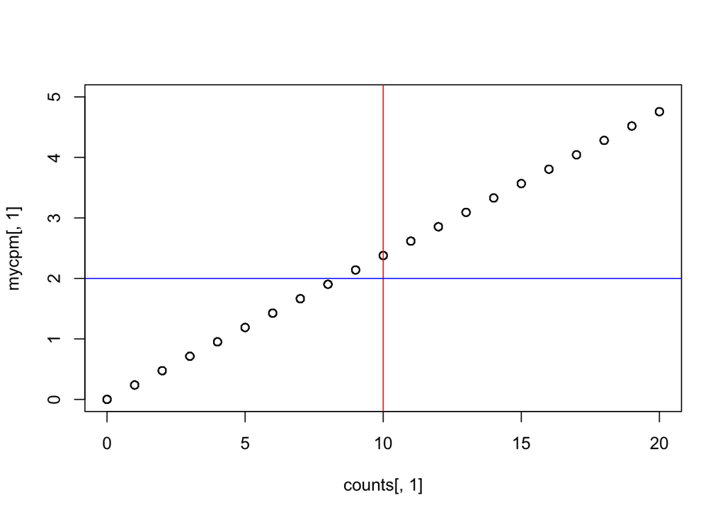

```r
mycpm <- cpm(counts)
plot(counts[,1],mycpm[,1],xlim=c(0,20),ylim=c(0,5))
abline(v=10,col=2)
abline(h=2,col=4)
```

We can filter on a CPM of 2 or 3 in at least 3 samples.

```r
thresh <- mycpm > 2
keep <- rowSums(thresh) >= 3
table(keep)
```

```
keep
FALSE  TRUE
 7345  7524
```

```r
counts.keep <- counts[keep,]
dim(counts.keep)
```

```
[1] 7524    7
```

We are filtering out about half our genes.

## Convert to DGEList object

```r
y <- DGEList(counts.keep)
```

## Quality control

Let’s do a number of quality control plots.

First, check the library sizes:

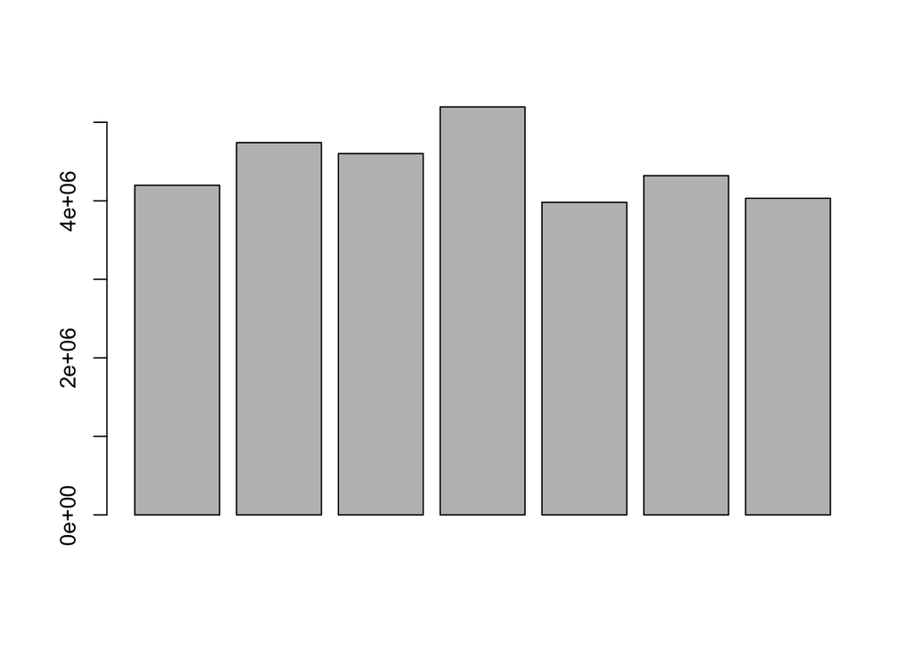

```r
barplot(y$samples$lib.size)
```

Next check the distribution of the counts using a boxplot:

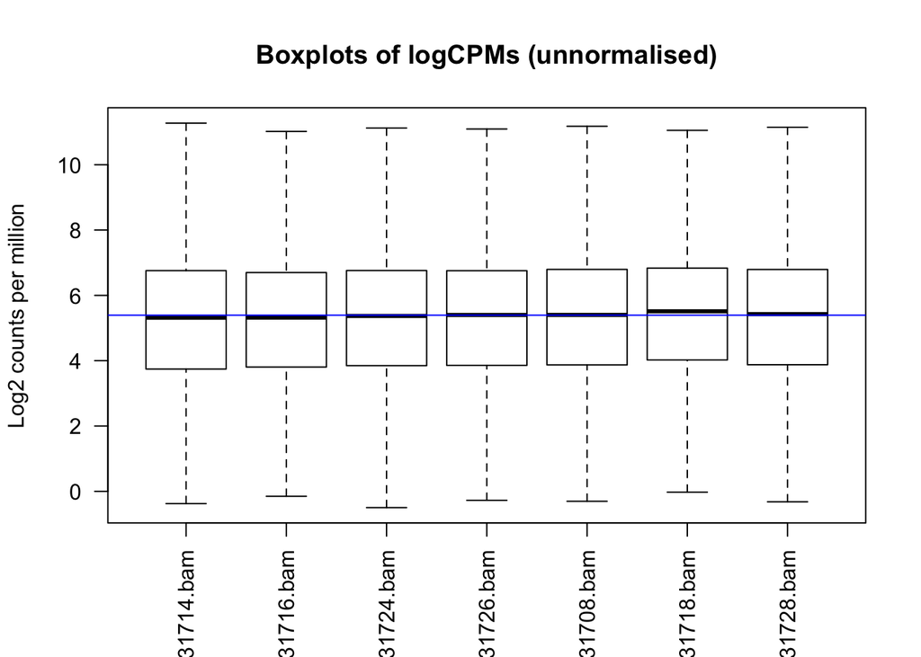

```r
par(mfrow=c(1,1))
# Get log2 counts per million
logcpm <- cpm(y$counts,log=TRUE)
# Check distributions of samples using boxplots
boxplot(logcpm, xlab="", ylab="Log2 counts per million",las=2,outline=FALSE)
# Let's add a blue horizontal line that corresponds to the median logCPM
abline(h=median(logcpm),col="blue")
title("Boxplots of logCPMs (unnormalised)")
```

We can colour by our groups, or by the different library prep.

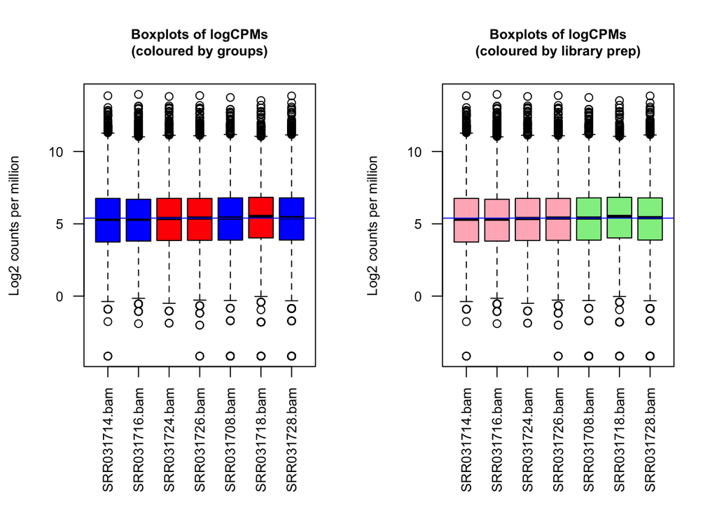

```r
par(mfrow=c(1,2),oma=c(2,0,0,0))
group.col <- c("red","blue")[targets$Group]
boxplot(logcpm, xlab="", ylab="Log2 counts per million",las=2,col=group.col,
        pars=list(cex.lab=0.8,cex.axis=0.8))
abline(h=median(logcpm),col="blue")
title("Boxplots of logCPMs\n(coloured by groups)",cex.main=0.8)

lib.col <- c("light pink","light green")[targets$Library]
boxplot(logcpm, xlab="", ylab="Log2 counts per million",las=2, col=lib.col,
        pars=list(cex.lab=0.8,cex.axis=0.8))
abline(h=median(logcpm),col="blue")
title("Boxplots of logCPMs\n(coloured by library prep)",cex.main=0.8)
```

It doesn’t look like there are any large biases in the data.

Finally, let’s check our MDS plots.

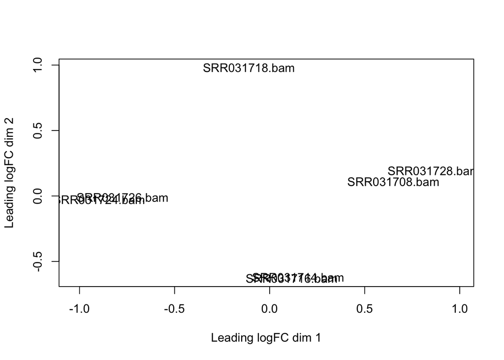

```r
par(mfrow=c(1,1))
plotMDS(y)
```

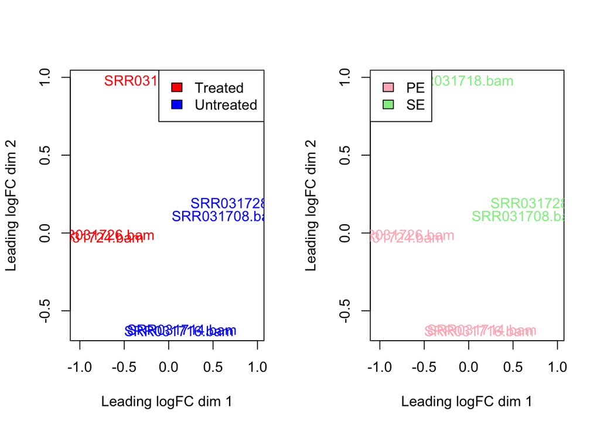

```r
par(mfrow=c(1,2))
plotMDS(y,col=group.col)
legend("topright",legend=levels(targets$Group),fill=c("red","blue"))
plotMDS(y,col=lib.col)
legend("topleft",legend=levels(targets$Library),fill=c("light pink","light green"))
```

It looks like there is some variability in the data due to library type e.g. single end or paired end.

## Hierarchical clustering with heatmap.2

First we need a matrix of log counts:

```r
logcounts <- cpm(y,log=TRUE)
```

Get variances for genes:

```r
var_genes <- apply(logcounts, 1, var)
```

Get top 500 most variable

```r
select_var <- names(sort(var_genes, decreasing=TRUE))[1:500]
```

```r
highly_variable_lcpm <- logcounts[select_var,]
dim(highly_variable_lcpm)
```

```
[1] 500   7
```

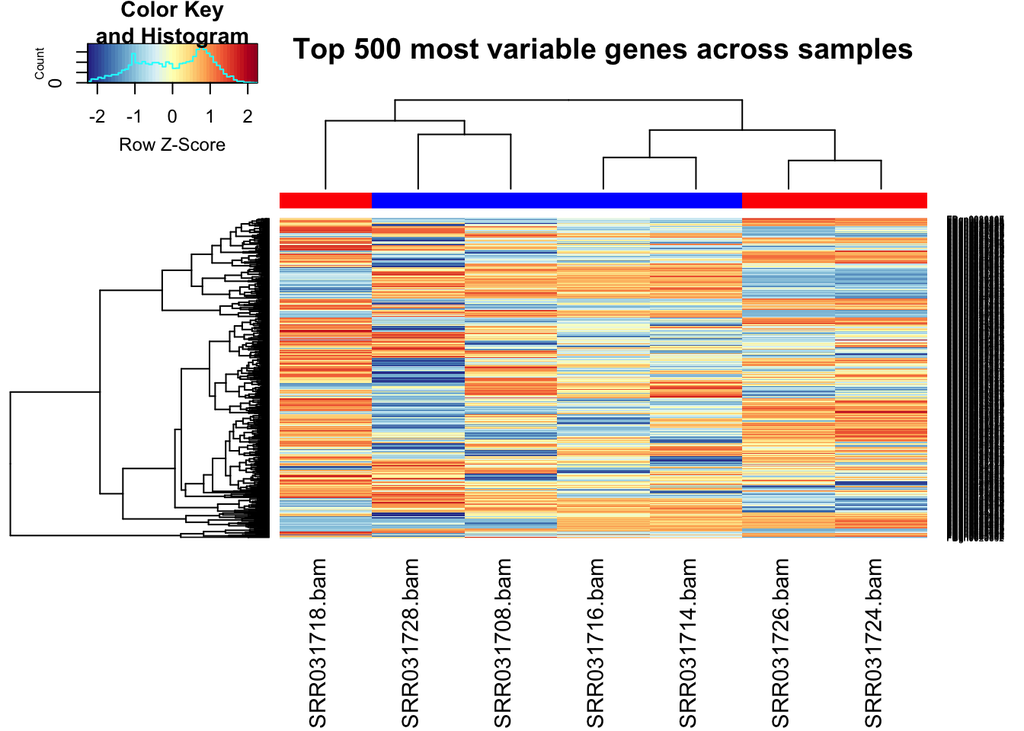

```r
mypalette <- brewer.pal(11,"RdYlBu")
morecols <- colorRampPalette(mypalette)
# Plot the heatmap
heatmap.2(highly_variable_lcpm,col=rev(morecols(50)),trace="none", main="Top 500 most variable genes across samples",ColSideColors=group.col,scale="row",margins=c(10,5))
```

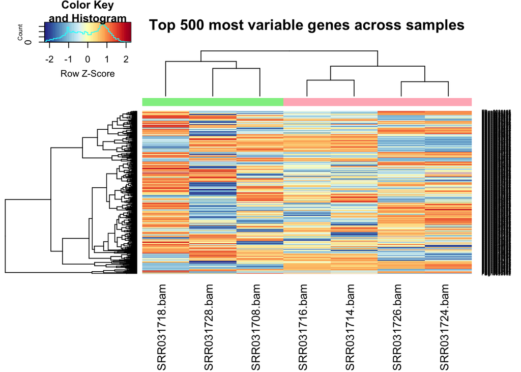

```r
heatmap.2(highly_variable_lcpm,col=rev(morecols(50)),trace="none", main="Top 500 most variable genes across samples",ColSideColors=lib.col,scale="row",margins=c(10,5))
```

## Normalisation

Let’s do TMM normalisation

```r
y <- calcNormFactors(y)
y$samples
```

```
              group lib.size norm.factors
SRR031714.bam     1  4198181    0.9805029
SRR031716.bam     1  4740969    0.9566649
SRR031724.bam     1  4601291    0.9936278
SRR031726.bam     1  5195516    1.0019699
SRR031708.bam     1  3980986    1.0036556
SRR031718.bam     1  4320527    1.0556860
SRR031728.bam     1  4031608    1.0106328
```

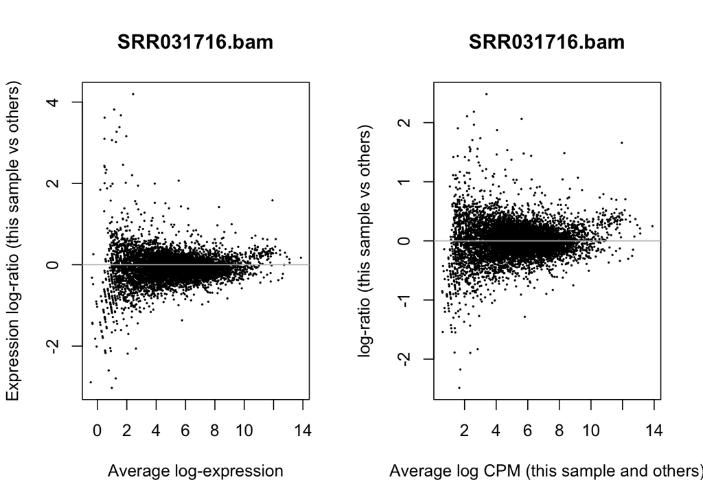

```r
par(mfrow=c(1,2))
plotMD(logcounts,column=2)
abline(h=0,col="grey")
plotMD(y,column = 2)
abline(h=0,col="grey")
```

## Differential expression

### Set up design matrix

We want to test for differences between the treated and untreated samples. However, we know that the library preparation adds variability to the data, so we need to account for it in our model. We do this by modelling both Group and Library as variables in our design matrix. This is known as an additive model.

```r
design <- model.matrix(~targets$Library + targets$Group)
design
```

```
  (Intercept) targets$LibrarySE targets$GroupUntreated
1           1                 0                      1
2           1                 0                      1
3           1                 0                      0
4           1                 0                      0
5           1                 1                      1
6           1                 1                      0
7           1                 1                      1
attr(,"assign")
[1] 0 1 2
attr(,"contrasts")
attr(,"contrasts")$`targets$Library`
[1] "contr.treatment"

attr(,"contrasts")$`targets$Group`
[1] "contr.treatment"
```

```r
colnames(design) <- c("Int","SEvsPE","UVsT")
```

### Voom transform the data

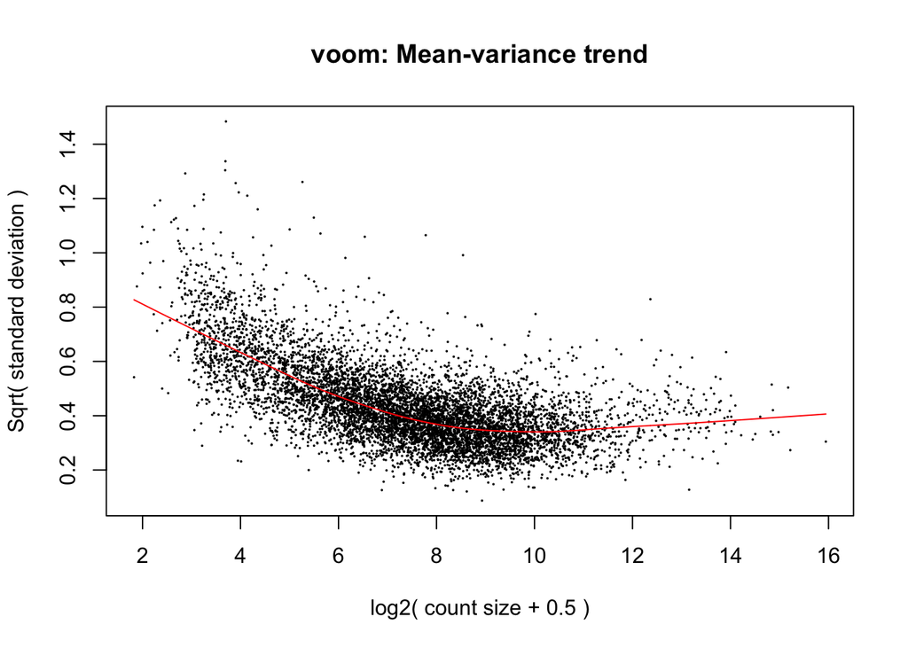

```r
par(mfrow=c(1,1))
v <- voom(y,design,plot=TRUE)
```

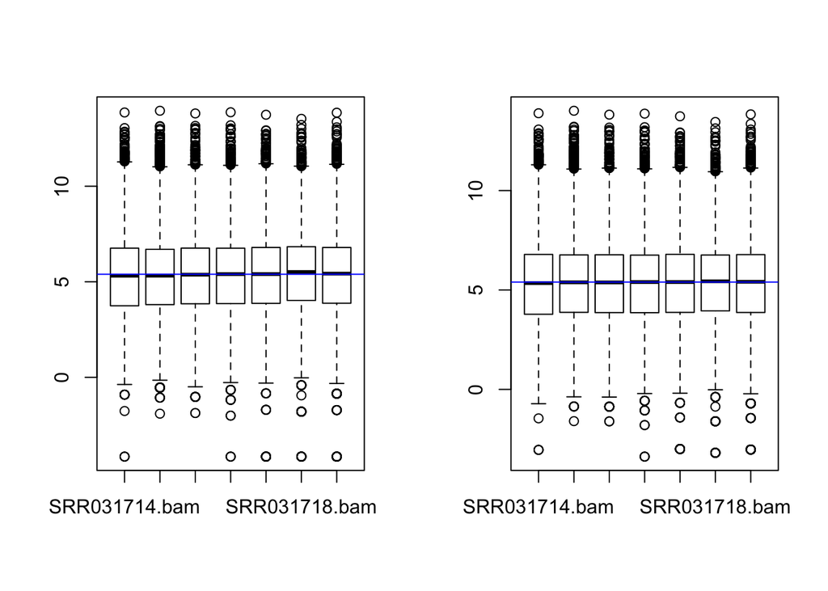

```r
par(mfrow=c(1,2))
boxplot(logcounts)
abline(h=median(logcounts),col=4)
boxplot(v$E)
abline(h=median(v$E),col=4)
```

### Test for differential expression

```r
fit <- lmFit(v,design)
fit <- eBayes(fit)
results <- decideTests(fit)
summary(results)
```

```
        Int SEvsPE UVsT
Down      4    125  440
NotSig   66   7142 6641
Up     7454    257  443
```

```r
topTable(fit,coef=3,sort.by="p")
```

```
                logFC   AveExpr         t      P.Value    adj.P.Val
FBgn0025111 -2.863110  6.253448 -31.24326 9.756044e-13 4.734428e-09
FBgn0003360  3.089242  7.778378  30.57062 1.258487e-12 4.734428e-09
FBgn0026562  2.422219 11.359837  24.25592 1.868075e-11 4.685133e-08
FBgn0029167  2.247086  7.825170  21.77945 6.509505e-11 1.224438e-07
FBgn0035085  2.677008  5.180607  18.97509 3.188148e-10 4.797524e-07
FBgn0039155  4.272254  4.800907  17.42222 8.476440e-10 1.062946e-06
FBgn0040091  1.559497  6.245766  15.43293 3.363833e-09 3.615639e-06
FBgn0023479  1.576335  7.768886  15.06473 4.419245e-09 3.877495e-06
FBgn0029896  2.312097  4.881577  15.00033 4.638152e-09 3.877495e-06
FBgn0027279  1.180272  7.760889  14.37303 7.503535e-09 5.645660e-06
                   B
FBgn0025111 19.04663
FBgn0003360 19.04370
FBgn0026562 16.57869
FBgn0029167 15.57725
FBgn0035085 13.66077
FBgn0039155 12.15024
FBgn0040091 11.72125
FBgn0023479 11.43434
FBgn0029896 11.25267
FBgn0027279 10.89435
```

### Add annotation from org.Dm.eg.db

The rownames of the fit object are http://flybase.org/ ids.

First we need to decide what information we want. In order to see what we can extract we can run the `columns` function on the annotation database.

```r
columns(org.Dm.eg.db)
```

```
 [1] "ACCNUM"       "ALIAS"        "ENSEMBL"      "ENSEMBLPROT"
 [5] "ENSEMBLTRANS" "ENTREZID"     "ENZYME"       "EVIDENCE"
 [9] "EVIDENCEALL"  "FLYBASE"      "FLYBASECG"    "FLYBASEPROT"
[13] "GENENAME"     "GO"           "GOALL"        "MAP"
[17] "ONTOLOGY"     "ONTOLOGYALL"  "PATH"         "PMID"
[21] "REFSEQ"       "SYMBOL"       "UNIGENE"      "UNIPROT"
```

We definitely want gene symbols and perhaps the full gene name and Entrez id. Let’s build up our annotation information in a separate data frame using the `select` function. Note, by default, the `select` function assumes that the keys provided are Entrez ids. However, in this case we are using FlyBase ids as the keys. As such, we need to give the `select` function this information using the `keytype` argument which we will set to `"FLYBASE"`.

```r
ann <- select(org.Dm.eg.db,keys=rownames(fit),columns=c("FLYBASE","ENTREZID","SYMBOL","GENENAME"),keytype="FLYBASE")
# Have a look at the annotation
head(ann)
```

```
      FLYBASE ENTREZID   SYMBOL
1 FBgn0037213    40522  CG12581
2 FBgn0053294  3772637  CR33294
3 FBgn0037215    40524 beta-Man
4 FBgn0037217    40526  CG14636
5 FBgn0037218    40527      aux
6 FBgn0261436    40528     DhpD
                                         GENENAME
1 CG12581 gene product from transcript CG12581-RB
2                                          pseudo
3                                beta-Mannosidase
4 CG14636 gene product from transcript CG14636-RA
5                                         auxilin
6                         Dihydropterin deaminase
```

Let’s double check that the `FLYBASE` column matches exactly to our `fit` rownames.

```r
table(ann$FLYBASE==rownames(fit))
```

```
TRUE
7524
```

We can slot in the annotation information into the `genes` slot of `fit`. (Please note that if the `select` function returns a 1:many mapping then you can’t just append the annotation to the fit object. An alternative way to get annotation is shown below.)

```r
fit$genes <- ann
```

Now when we run the `topTable` command, the annotation information should be included in the output.

```r
topTable(fit,coef=3,sort.by="p")
```

```
                FLYBASE ENTREZID    SYMBOL
FBgn0025111 FBgn0025111    32008      Ant2
FBgn0003360 FBgn0003360    32007      sesB
FBgn0026562 FBgn0026562    43230     SPARC
FBgn0029167 FBgn0029167    39529       Hml
FBgn0035085 FBgn0035085    37991    CG3770
FBgn0039155 FBgn0039155    42865      Kal1
FBgn0040091 FBgn0040091    37590   Ugt58Fa
FBgn0023479 FBgn0023479    39048       teq
FBgn0029896 FBgn0029896    31612    CG3168
FBgn0027279 FBgn0027279    33137 l(1)G0196
                                                 GENENAME     logFC
FBgn0025111              Adenine nucleotide translocase 2 -2.863110
FBgn0003360                            stress-sensitive B  3.089242
FBgn0026562       Secreted protein, acidic, cysteine-rich  2.422219
FBgn0029167                                    Hemolectin  2.247086
FBgn0035085 CG3770 gene product from transcript CG3770-RA  2.677008
FBgn0039155                           Kallmann syndrome 1  4.272254
FBgn0040091 CG4414 gene product from transcript CG4414-RB  1.559497
FBgn0023479                                       Tequila  1.576335
FBgn0029896 CG3168 gene product from transcript CG3168-RG  2.312097
FBgn0027279                              lethal (1) G0196  1.180272
              AveExpr         t      P.Value    adj.P.Val        B
FBgn0025111  6.253448 -31.24326 9.756044e-13 4.734428e-09 19.04663
FBgn0003360  7.778378  30.57062 1.258487e-12 4.734428e-09 19.04370
FBgn0026562 11.359837  24.25592 1.868075e-11 4.685133e-08 16.57869
FBgn0029167  7.825170  21.77945 6.509505e-11 1.224438e-07 15.57725
FBgn0035085  5.180607  18.97509 3.188148e-10 4.797524e-07 13.66077
FBgn0039155  4.800907  17.42222 8.476440e-10 1.062946e-06 12.15024
FBgn0040091  6.245766  15.43293 3.363833e-09 3.615639e-06 11.72125
FBgn0023479  7.768886  15.06473 4.419245e-09 3.877495e-06 11.43434
FBgn0029896  4.881577  15.00033 4.638152e-09 3.877495e-06 11.25267
FBgn0027279  7.760889  14.37303 7.503535e-09 5.645660e-06 10.89435
```

If for some reason the `select` function doesn’t work, or the result is a 1:many mapping, there is a less elegant way to get the annotations using the `toTable` command.

```r
# Let's see what we can get in table format from org.Dm.eg.db
ls("package:org.Dm.eg.db")
```

```
 [1] "org.Dm.eg"                "org.Dm.eg_dbconn"
 [3] "org.Dm.eg_dbfile"         "org.Dm.eg_dbInfo"
 [5] "org.Dm.eg_dbschema"       "org.Dm.eg.db"
 [7] "org.Dm.egACCNUM"          "org.Dm.egACCNUM2EG"
 [9] "org.Dm.egALIAS2EG"        "org.Dm.egCHR"
[11] "org.Dm.egCHRLENGTHS"      "org.Dm.egCHRLOC"
[13] "org.Dm.egCHRLOCEND"       "org.Dm.egENSEMBL"
[15] "org.Dm.egENSEMBL2EG"      "org.Dm.egENSEMBLPROT"
[17] "org.Dm.egENSEMBLPROT2EG"  "org.Dm.egENSEMBLTRANS"
[19] "org.Dm.egENSEMBLTRANS2EG" "org.Dm.egENZYME"
[21] "org.Dm.egENZYME2EG"       "org.Dm.egFLYBASE"
[23] "org.Dm.egFLYBASE2EG"      "org.Dm.egFLYBASECG"
[25] "org.Dm.egFLYBASECG2EG"    "org.Dm.egFLYBASEPROT"
[27] "org.Dm.egFLYBASEPROT2EG"  "org.Dm.egGENENAME"
[29] "org.Dm.egGO"              "org.Dm.egGO2ALLEGS"
[31] "org.Dm.egGO2EG"           "org.Dm.egMAP"
[33] "org.Dm.egMAP2EG"          "org.Dm.egMAPCOUNTS"
[35] "org.Dm.egORGANISM"        "org.Dm.egPATH"
[37] "org.Dm.egPATH2EG"         "org.Dm.egPMID"
[39] "org.Dm.egPMID2EG"         "org.Dm.egREFSEQ"
[41] "org.Dm.egREFSEQ2EG"       "org.Dm.egSYMBOL"
[43] "org.Dm.egSYMBOL2EG"       "org.Dm.egUNIGENE"
[45] "org.Dm.egUNIGENE2EG"      "org.Dm.egUNIPROT"
```

```r
# Get annotation
fly <- toTable(org.Dm.egFLYBASE)
head(fly)
```

```
  gene_id  flybase_id
1   30970 FBgn0040373
2   30971 FBgn0040372
3   30972 FBgn0261446
4   30973 FBgn0000316
5   30975 FBgn0005427
6   30976 FBgn0040370
```

```r
symbol <- toTable(org.Dm.egSYMBOL)
genename <- toTable(org.Dm.egGENENAME)

# We can use the merge command to merge two dataframes
ann1 <- merge(fly,symbol,by="gene_id")
head(ann1)
```

```
   gene_id  flybase_id  symbol
1 10178776 FBgn0261702 CR42738
2 10178777 FBgn0262024 CG42835
3 10178779 FBgn0058354 CR40354
4 10178780 FBgn0053929 CR33929
5 10178781 FBgn0262141 CG42867
6 10178782 FBgn0062978 CG31808
```

```r
# Add genename table to ann1
ann2 <- merge(ann1,genename,by="gene_id")
head(ann2)
```

```
   gene_id  flybase_id  symbol
1 10178776 FBgn0261702 CR42738
2 10178777 FBgn0262024 CG42835
3 10178779 FBgn0058354 CR40354
4 10178780 FBgn0053929 CR33929
5 10178781 FBgn0262141 CG42867
6 10178782 FBgn0062978 CG31808
                                        gene_name
1                                           ncRNA
2 CG42835 gene product from transcript CG42835-RA
3                                          pseudo
4                                          pseudo
5 CG42867 gene product from transcript CG42867-RB
6 CG31808 gene product from transcript CG31808-RC
```

Now we need to match up between `rownames(fit)` and the ensemble gene id in `ann2`.

```r
m <- match(rownames(fit),ann2$flybase_id)
table(is.na(m)) # check for unmatched rows
```

```
FALSE  TRUE
 6973   551
```

```r
ann3 <- ann2[m[!is.na(m)],] # exclude unmatched rows

# compare the results in ann3 to what is in the fit object
head(ann3)
```

```
      gene_id  flybase_id   symbol
16194   40522 FBgn0037213  CG12581
13730 3772637 FBgn0053294  CR33294
16195   40524 FBgn0037215 beta-Man
16196   40526 FBgn0037217  CG14636
16197   40527 FBgn0037218      aux
16198   40528 FBgn0261436     DhpD
                                            gene_name
16194 CG12581 gene product from transcript CG12581-RB
13730                                          pseudo
16195                                beta-Mannosidase
16196 CG14636 gene product from transcript CG14636-RA
16197                                         auxilin
16198                         Dihydropterin deaminase
```

```r
head(fit$genes)
```

```
      FLYBASE ENTREZID   SYMBOL
1 FBgn0037213    40522  CG12581
2 FBgn0053294  3772637  CR33294
3 FBgn0037215    40524 beta-Man
4 FBgn0037217    40526  CG14636
5 FBgn0037218    40527      aux
6 FBgn0261436    40528     DhpD
                                         GENENAME
1 CG12581 gene product from transcript CG12581-RB
2                                          pseudo
3                                beta-Mannosidase
4 CG14636 gene product from transcript CG14636-RA
5                                         auxilin
6                         Dihydropterin deaminase
```

```r
topTable(fit,coef=3,sort.by="p")
```

```
                FLYBASE ENTREZID    SYMBOL
FBgn0025111 FBgn0025111    32008      Ant2
FBgn0003360 FBgn0003360    32007      sesB
FBgn0026562 FBgn0026562    43230     SPARC
FBgn0029167 FBgn0029167    39529       Hml
FBgn0035085 FBgn0035085    37991    CG3770
FBgn0039155 FBgn0039155    42865      Kal1
FBgn0040091 FBgn0040091    37590   Ugt58Fa
FBgn0023479 FBgn0023479    39048       teq
FBgn0029896 FBgn0029896    31612    CG3168
FBgn0027279 FBgn0027279    33137 l(1)G0196
                                                 GENENAME     logFC
FBgn0025111              Adenine nucleotide translocase 2 -2.863110
FBgn0003360                            stress-sensitive B  3.089242
FBgn0026562       Secreted protein, acidic, cysteine-rich  2.422219
FBgn0029167                                    Hemolectin  2.247086
FBgn0035085 CG3770 gene product from transcript CG3770-RA  2.677008
FBgn0039155                           Kallmann syndrome 1  4.272254
FBgn0040091 CG4414 gene product from transcript CG4414-RB  1.559497
FBgn0023479                                       Tequila  1.576335
FBgn0029896 CG3168 gene product from transcript CG3168-RG  2.312097
FBgn0027279                              lethal (1) G0196  1.180272
              AveExpr         t      P.Value    adj.P.Val        B
FBgn0025111  6.253448 -31.24326 9.756044e-13 4.734428e-09 19.04663
FBgn0003360  7.778378  30.57062 1.258487e-12 4.734428e-09 19.04370
FBgn0026562 11.359837  24.25592 1.868075e-11 4.685133e-08 16.57869
FBgn0029167  7.825170  21.77945 6.509505e-11 1.224438e-07 15.57725
FBgn0035085  5.180607  18.97509 3.188148e-10 4.797524e-07 13.66077
FBgn0039155  4.800907  17.42222 8.476440e-10 1.062946e-06 12.15024
FBgn0040091  6.245766  15.43293 3.363833e-09 3.615639e-06 11.72125
FBgn0023479  7.768886  15.06473 4.419245e-09 3.877495e-06 11.43434
FBgn0029896  4.881577  15.00033 4.638152e-09 3.877495e-06 11.25267
FBgn0027279  7.760889  14.37303 7.503535e-09 5.645660e-06 10.89435
```

Let’s check the expression of pasilla.

```r
ps <- grep("pasilla",fit$genes$GENENAME)
topTable(fit[ps,],coef=3)
```

```
                FLYBASE ENTREZID SYMBOL GENENAME    logFC  AveExpr       t
FBgn0261552 FBgn0261552    44258     ps  pasilla 1.845368 8.344996 11.5651
                P.Value   adj.P.Val        B
FBgn0261552 8.37355e-08 8.37355e-08 8.425095
```

## Plots after testing for DE

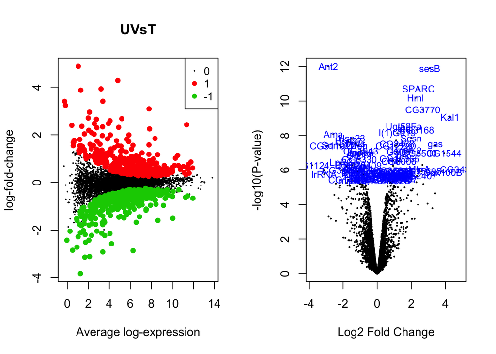

```r
par(mfrow=c(1,2))
plotMD(fit,coef=3,status=results[,"UVsT"])

volcanoplot(fit,coef=3,highlight=100,names=fit$genes$SYMBOL)
```

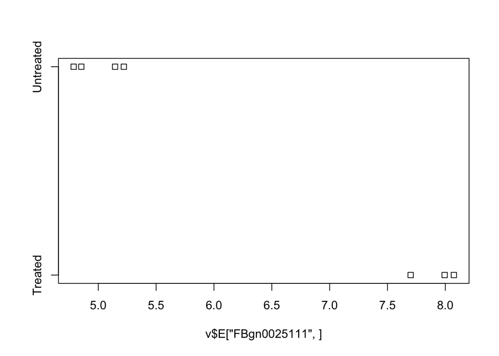

```r
stripchart(v$E["FBgn0025111",]~targets$Group)
```

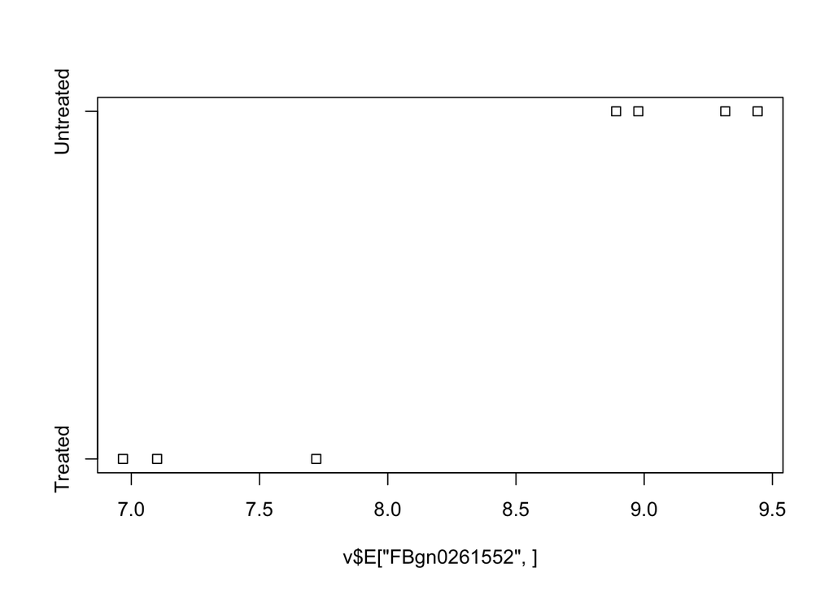

```r
# Check expression of Pasilla
stripchart(v$E["FBgn0261552",]~targets$Group)
```

## Testing relative to a threshold

```r
fit.treat <- treat(fit,lfc=1)
res.treat <- decideTests(fit.treat)
summary(res.treat)
```

```
        Int SEvsPE UVsT
Down      2     13   10
NotSig  350   7510 7496
Up     7172      1   18
```

```r
topTreat(fit.treat,coef=3)
```

```
                FLYBASE ENTREZID SYMBOL
FBgn0003360 FBgn0003360    32007   sesB
FBgn0025111 FBgn0025111    32008   Ant2
FBgn0026562 FBgn0026562    43230  SPARC
FBgn0039155 FBgn0039155    42865   Kal1
FBgn0029167 FBgn0029167    39529    Hml
FBgn0035085 FBgn0035085    37991 CG3770
FBgn0034736 FBgn0034736    37572    gas
FBgn0000071 FBgn0000071    40831    Ama
FBgn0029896 FBgn0029896    31612 CG3168
FBgn0039827 FBgn0039827    43689 CG1544
                                                 GENENAME     logFC
FBgn0003360                            stress-sensitive B  3.089242
FBgn0025111              Adenine nucleotide translocase 2 -2.863110
FBgn0026562       Secreted protein, acidic, cysteine-rich  2.422219
FBgn0039155                           Kallmann syndrome 1  4.272254
FBgn0029167                                    Hemolectin  2.247086
FBgn0035085 CG3770 gene product from transcript CG3770-RA  2.677008
FBgn0034736                                      gasoline  3.407306
FBgn0000071                                       Amalgam -2.572434
FBgn0029896 CG3168 gene product from transcript CG3168-RG  2.312097
FBgn0039827 CG1544 gene product from transcript CG1544-RA  3.925533
              AveExpr          t      P.Value    adj.P.Val
FBgn0003360  7.778378  20.674784 5.940461e-11 2.711163e-07
FBgn0025111  6.253448 -20.330911 7.206708e-11 2.711163e-07
FBgn0026562 11.359837  14.241997 4.158446e-09 1.042938e-05
FBgn0039155  4.800907  13.344224 8.653631e-09 1.627748e-05
FBgn0029167  7.825170  12.087142 2.578989e-08 3.880863e-05
FBgn0035085  5.180607  11.886920 3.099362e-08 3.886600e-05
FBgn0034736  3.372966   8.780952 7.931358e-07 8.094637e-04
FBgn0000071  4.209333  -8.710932 8.606738e-07 8.094637e-04
FBgn0029896  4.881577   8.512571 1.091548e-06 8.898178e-04
FBgn0039827  3.204658   8.449359 1.182639e-06 8.898178e-04
```

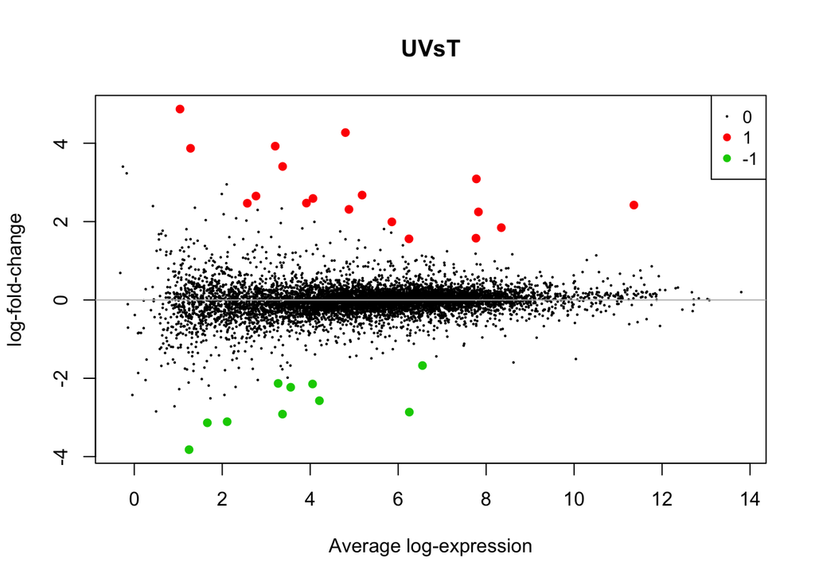

```r
plotMD(fit.treat,coef=3,status=res.treat[,"UVsT"])
abline(h=0,col="grey")
```

## Gene set testing with goana

```r
go <- goana(fit, coef="UVsT",species = "Dm", geneid="ENTREZID")
topGO(go, n=10)
```

```
                                                 Term Ont   N Up Down
GO:0019991                  septate junction assembly  BP  31  1   13
GO:0043297                   apical junction assembly  BP  40  1   13
GO:0060856       establishment of blood-brain barrier  BP  14  0    8
GO:0007043                cell-cell junction assembly  BP  41  1   13
GO:0005886                            plasma membrane  CC 562 52   62
GO:0071944                             cell periphery  CC 646 59   68
GO:0034329                     cell junction assembly  BP  46  1   13
GO:0005576                       extracellular region  CC 292 38   38
GO:0044421                  extracellular region part  CC 193 25   29
GO:0060857 establishment of glial blood-brain barrier  BP  13  0    7
                   P.Up       P.Down
GO:0019991 8.449142e-01 6.306908e-09
GO:0043297 9.098680e-01 2.261935e-07
GO:0060856 1.000000e+00 2.878201e-07
GO:0007043 9.151462e-01 3.137986e-07
GO:0005886 4.582709e-04 5.482216e-07
GO:0071944 2.604236e-04 8.324520e-07
GO:0034329 9.372556e-01 1.383728e-06
GO:0005576 1.934484e-06 2.315881e-06
GO:0044421 1.256161e-04 2.218933e-06
GO:0060857 1.000000e+00 2.862652e-06
```